# Lecture 04: Finding your Psychology

## OSF (Open Science Foundation)

[OSF | When Research is Mesearch: How Researchers’ Motivation to Pursue a Topic Affects Laypeople’s Trust in Science](https://osf.io/phfq3/) [https://osf.io/phfq3/](http://127.0.0.1:26677/#0)

[figure not shown]

## Open Data and Open Materials

[figure not shown]

## Open Data

[figure not shown]

## Open Materials

[figure not shown]

## Psyarxiv

[figure not shown]

# Questions?

## Lab activities

Keep working!

Formalise your individual design

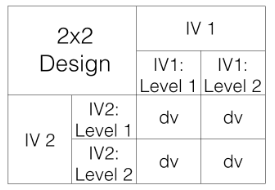

## More specific

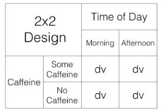

## This is my design

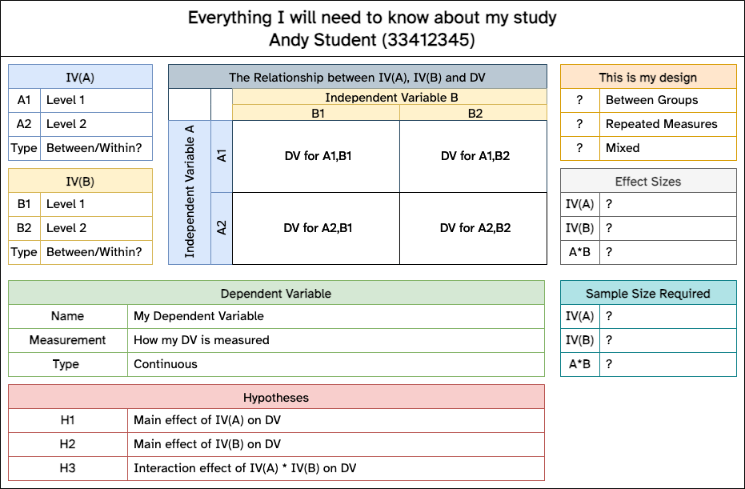

## Notation

We use a notation system to refer to these designs:

2x2 = Two-way ANOVA. There are two IVS, the first IV has two levels, the second IV has 2 levels. There are a total of 4 conditions, 2x2 = 4.

2x3 = Two-way ANOVA. There are two IVs, the first IV has two levels, the second IV has three levels. There are a total of 6 conditions, 2x3 = 6

4x4 = Two-way ANOVA. There are two IVs, the first IV has 4 levels, the second IV has 4 levels. There are a total of 16 conditions, 4x4=16

**2x3x2 = Three-way ANOVA**.There are a total of three IVs. The first IV has 2 levels. The second IV has 3 levels. The third IV has 2 levels. There are a total of 12 conditions. 2x3x2 = 12.

## Review

[Crump, M. J. C., Navarro, D. J., & Suzuki, J. (2019, June 5). Answering Questions with Data (Textbook): Introductory Statistics for Psychology Students. https://doi.org/10.17605/OSF.IO/JZE52](https://crumplab.github.io/statistics/)

CC BY SA 4.0

https://crumplab.com/statistics/07-ANOVA.html

https://crumplab.com/statistics/10-MixedANOVA.html#x2-designs

## 3 ‘flavours’ of 2x2 ANOVA

**2bx2b** - Between-subjects/Factorial ANOVA

**2wx2w** - Within-subject/Repeated Measures ANOVA

**2bx2w** or **2wx2b** - Mixed ANOVA

You will be using one of these (all supported by SPSS Exercises 1 & 2)

JAMOVI is a reasonable alternative to SPSS (R is even better - much more value as a skill)

## The 3 effects possible in a 2x2 ANOVA

Main effect of IV1

Main effect of IV2

Interaction of IV1*IV2

## therefore 8 possible ‘outcomes’ of a 2x2 ANOVA

- no IV1 main effect, no IV2 main effect, no interaction
- IV1 main effect, no IV2 main effect, no interaction
- IV1 main effect, no IV2 main effect, interaction
- IV1 main effect, IV2 main effect, no interaction
- IV1 main effect, IV2 main effect, interaction
- no IV1 main effect, IV2 main effect, no interaction
- no IV1 main effect, IV2 main effect, interaction
- no IV1 main effect, no IV2 main effect, interaction

## graph key

- 1 = there was a main effect for IV1.
- ~1 = there was **not** a main effect for IV1
- 2 = there was a main effect for IV2
- ~2 = there was **not** a main effect of IV2
- 1x2 = there was an interaction
- ~1x2 = there was **not** an interaction

## Bar charts

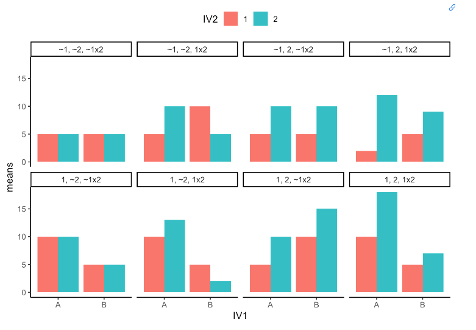

## Line plots

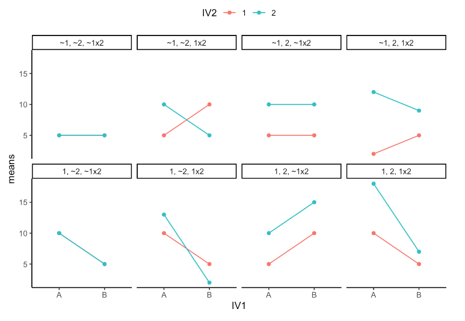

## References

Research Methods Lecture 04 - MeSearch or Research

Walmsley, J. (2001). Normalisation, Emancipatory Research and Inclusive Research in Learning Disability. *Disability & Society*, *16*(2), 187–205. https://doi.org/10.1080/09687590120035807